# Series_de_Tiempo_Primer_Parcial_Ibarra_Sergio

### A.6 Calculo del error tipo MAPE para los pronósticos hechos con los modelos estáticos de suavizamiento

Calculemos el error tipo MAPE entre los valores pronosticados con el “método de suavizamiento estático” y los valores reales de la serie

```r
##Primero formemos un vector con los valores reales
Demanda_electrico_completa_reales12 <- Demanda_electrico_completa$Demanded_Gas[202:213]
Demanda_electrico_completa_reales12
```

```
##  [1] 4417.51 4557.36 4538.89 3320.75 3449.80 3206.96 3403.44 3350.03 3498.70
## [10] 3350.97 3506.42 3778.37
```

```r
## Despues formemos un vector con únicamente los valores pronósticados
Demanda_electrico_E_forecast12 <- Demanda_electrico_pronostico_ajustado[202:213]
Demanda_electrico_E_forecast12
```

```
##
## 4170.880 4317.491 3877.669 3838.677 4213.452 4360.360 3916.396 3876.587
##
## 4254.958 4403.928 3955.429 3915.458
```

```r
##Calculemos el MAPE entre estos dos vectores

# First, calculate the absolute percentage error (APE) for each element in the vectors
APE_electrico_estatico <- abs((Demanda_electrico_completa_reales12 - Demanda_electrico_E_forecast12) / Demanda_electrico_completa_reales12)

# Calculate the mean APE across all elements in the vectors
MAPE_electrico_estatico <- mean(APE_electrico_estatico) * 100

# Print the MAPE value
cat("El error tipo MAPE  para el forecast calculado con el método de 'suavizamiento estático'de la serie de demanda de gas natural en el sector eléctrico es:", MAPE_electrico_estatico, "%")
```

```
## El error tipo MAPE  para el forecast calculado con el método de 'suavizamiento estático'de la serie de demanda de gas natural en el sector eléctrico es: 16.61447 %
```

## B. Método de suavizamiento dinámico ó Holt-winters

Vamos a usar ahora el método de HoltWinters como “modelo de suaviazamiento y pronóstico NO ESTÁTICO” que si considera los cambios de nivel a tráves del tiempo.

Para ello debemos tener nuestra data a suavizar en el tipo de dato serie de tiempo ts en R

```r
Demanda_electrico_ts <-ts(Demanda_electrico$Demanded_Gas, frequency =12, start =c(2005,1))
head(Demanda_electrico_ts)
```

```
##          Jan     Feb     Mar     Apr     May     Jun
## 2005 1819.58 1895.33 1765.86 1642.70 1895.54 2051.72
```

```r
tail(Demanda_electrico_ts)
```

```
##          Apr     May     Jun     Jul     Aug     Sep
## 2021 4104.82 4243.93 4985.53 4631.85 4098.81 4424.39
```

Graficamos la “data original de la demanda_electrico” que se usará como “train para el modelo” y que fue convertida a tipo de dato serie de tiempo

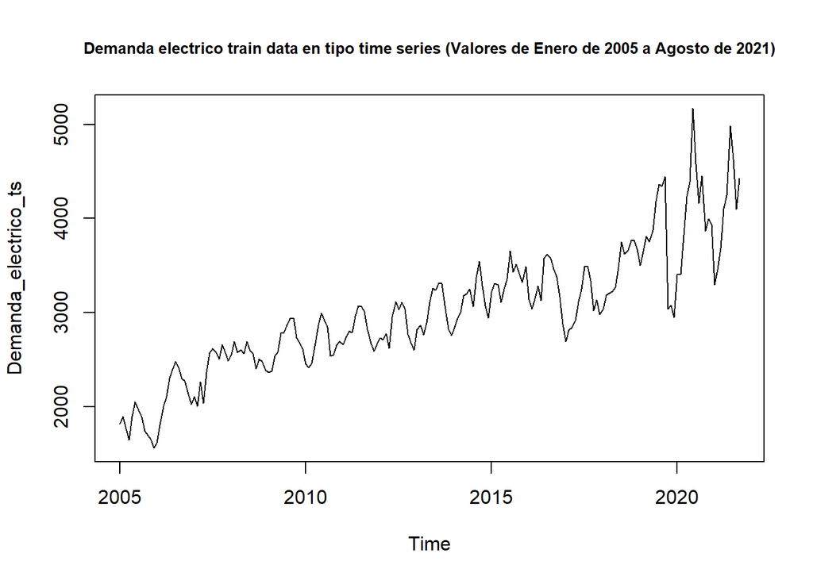

```r
plot(Demanda_electrico_ts, main="Demanda electrico train data en tipo time series (Valores de Enero de 2005 a Agosto de 2021)", cex.main=0.8)
```

### Aplicación del método de Holt Winters” a la serie CON TENDENCIA y CON ESTACIONALIDAD de demanda de gas en el sector eléctrico

Como se observará para este primer cálculo se dejará como ‘grados de libertad’ los valores de alpha, gamma y betha, así como los valores de arranque, de manera que el “el algoritmo de HltWinters de R” determine la “mejor combinaión posible” Recordar también que para la presente serie se está asumiendo un efecto multiplicativo de los factores estacionales

```r
Demanda_electrico_ts_hw1 <-HoltWinters(Demanda_electrico_ts, seasonal = 'multiplicative')
Demanda_electrico_ts_hw1
```

```
## Holt-Winters exponential smoothing with trend and multiplicative seasonal component.
##
## Call:
## HoltWinters(x = Demanda_electrico_ts, seasonal = "multiplicative")
##
## Smoothing parameters:
##  alpha: 0.8778578
##  beta : 0.004262188
##  gamma: 1
##
## Coefficients:
##             [,1]
## a   4083.8396737
## b     22.0244141
## s1     0.9346142
## s2     0.9328241
## s3     0.8821197
## s4     0.8525012
## s5     0.8813576
## s6     0.9252482
## s7     0.9699071
## s8     1.0226685
## s9     1.1390634
## s10    1.1151142
## s11    1.0804254
## s12    1.0833897
```

#### Interpretación de los valores de los coeficientes del método de Holt Winters para el caso de la serie de demanda de gas natural en el sector eléctrico en México

Interpretación de los valores de coficientes $\alpha$, $\beta$ y $\gamma$ para el caso del pronóstico usando modelo de HoltWinters SIN ESPECIFICAR DATOS DE ARRANQUE

$$0<\alpha<1$$

Recordemos que: Valores de $\alpha$ cercano a 1 reflejan caminata aleatoria Valores de $\alpha$ cercano a 0 reflejan una “gran influencia” de los valores pasado, es decir, que “el ruido no es un componente de gran relevancia”

En nuestro caso el valor de $\alpha$ es:

```r
Demanda_electrico_ts_hw1$alpha
```

```
##     alpha
## 0.8778578
```

Lo que indica que “La data historica NO tiene mayor relevancia vs el componente estocástico”

$$0<\beta<1$$
Recordemos que: Valores de $\beta$ cercano a 1 reflejan cambios CONSTANTES de nivel a lo largo de la serie Valores de $\beta$ cercano a 0 reflejan POCOS cambios de nivel a lo largo de la serie

En nuestro caso el valor de $\beta$ es:

```r
Demanda_electrico_ts_hw1$beta
```

```
##        beta
## 0.004262188
```

Lo que indica muy pocos cambios de nivel a lo largo de la serie o una especie de “pendiente constante”

Y entonces para el caso de valores de $\alpha$ cercanos a 1 y de $\beta$ cercanos a cero (como es nuestra serie de demanda_electrico) indica una serie con TENDENCIA ESTABLE y con CAMBIOS DE NIVEL MUY BAJOS

Afortunadamente no obtuvimos simultaneamente valores de$\alpha$ cercanos a 1 y de $\beta$ cercanos a 1 pues eso reflejaría una CAMINATA ALEATORIA con tendencia estocástica que sería prácticamente imposible de pronósticar.

$$0<\gamma<1$$
Recordemos que: Valores de $\gamma$ cercano a 1 reflejan cambios CONSTANTES de los factores de estacionalidad a lo largo de la serie Valores de $\gamma$ cercano a 0 reflejan POCOS cambios en los factores de estacionalidad a lo largo de la serie

En nuestro caso el valor de $\gamma$ es:

```r
Demanda_electrico_ts_hw1$gamma
```

```
## gamma
##     1
```

Lo que indica que cada dato nuevo en la serie cambia el valor del factor de estacionalidad

### Pronóstico de la serie de demanda de gas en el sector eléctrico con el método de Holt Winters

Ahora pasemos a realizar los pronósticos de la serie pero con el método de HoltWinters que considera cambios dinámicos de nivel

Graficamos los valores originales vs suavizados con el método de Holt-Winters

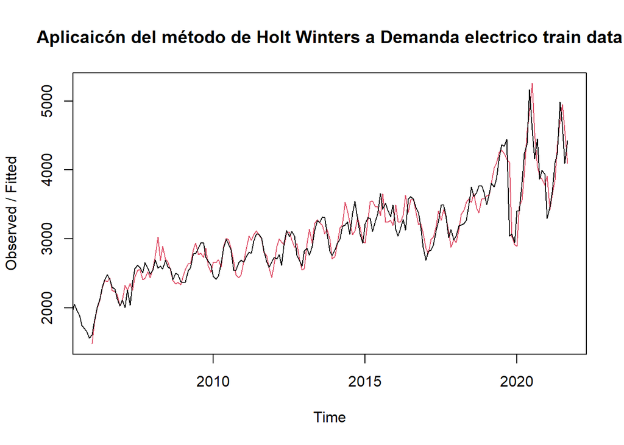

```r
plot(Demanda_electrico_ts_hw1, main="Aplicaicón del método de Holt Winters a Demanda electrico train data")
```

```r
# Load the forecast package
library(forecast)
```

Ahora se llevará a cabo el pronóstico con la librería de forecast y basados en el método de Holt Winters. De igual manera se usará un intervalo de confianza del 95%

```r
Demanda_electrico_ts_hw1_fc <- forecast(Demanda_electrico_ts_hw1, h=12, level=0.95)
Demanda_electrico_ts_hw1_fc
```

```
##          Point Forecast    Lo 95    Hi 95
## Oct 2021       3837.399 3431.808 4242.989
## Nov 2021       3850.594 3310.345 4390.843
## Dec 2021       3660.720 3033.263 4288.176
## Jan 2022       3556.581 2849.617 4263.546
## Feb 2022       3696.380 2882.393 4510.367
## Mar 2022       3900.834 2974.030 4827.637
## Apr 2022       4110.477 3073.869 5147.084
## May 2022       4356.604 3204.684 5508.524
## Jun 2022       4877.537 3544.382 6210.692
## Jul 2022       4799.545 3440.987 6158.102
## Aug 2022       4674.037 3304.396 6043.679
## Sep 2022       4710.722 3345.397 6076.047
```

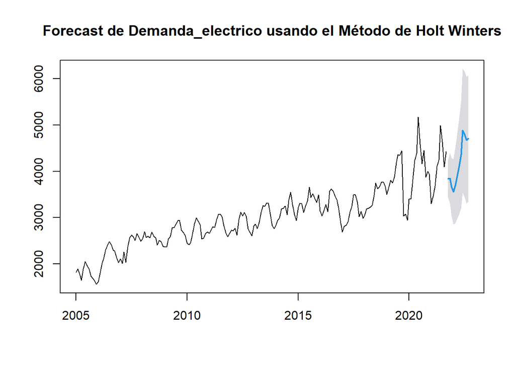

```r
plot(Demanda_electrico_ts_hw1_fc, main="Forecast de Demanda_electrico usando el Método de Holt Winters")
```

Veamos el valor la Suma de Errores al Cuadrado del pronóstico de la demanda de gas natural en el sector eléctrico usando el Método de suaviazamiento dinámico de HoltWinters

```r
Demanda_electrico_ts_hw1$SSE
```

```
## [1] 8118743
```

Calculemos el error tipo MAPE entre los valores pronosticados con el “método de Holt Winters” y los valores reales de la serie

```r
## Formemos un vector con únicamente los valores pronósticados
Demanda_electrico_HW_forecast12 <- Demanda_electrico_ts_hw1_fc$mean
Demanda_electrico_HW_forecast12
```

```
##           Jan      Feb      Mar      Apr      May      Jun      Jul      Aug
## 2021
## 2022 3556.581 3696.380 3900.834 4110.477 4356.604 4877.537 4799.545 4674.037
##           Sep      Oct      Nov      Dec
## 2021          3837.399 3850.594 3660.720
## 2022 4710.722
```

```r
##Calculemos el MAPE entre estos dos vectores

# First, calculate the absolute percentage error (APE) for each element in the vectors
APE_electrico_HW <- abs((Demanda_electrico_completa_reales12 - Demanda_electrico_HW_forecast12) / Demanda_electrico_completa_reales12)

# Calculate the mean APE across all elements in the vectors
MAPE_electrico_HW <- mean(APE_electrico_HW) * 100

# Print the MAPE value
cat("MAPE error para el forecast calculado con el método de 'HoltWinters'es:", MAPE_electrico_HW, "%")
```

```
## MAPE error para el forecast calculado con el método de 'HoltWinters'es: 22.9424 %
```

### Error cuadrado calculado con el Método de HoltWinters vs el calculado con el método de suafizamiento estático

```r
Demanda_electrico_ts_hw1$SSE
```

```
## [1] 8118743
```

Entonces el error asociado al pronóstico del cálculo de pronóstico PUNTUAL para el caso Demanda_eléctirco es:

```r
sse_Demanda_electrico_hw <- ((Demanda_electrico_ts_hw1$SSE)/(length(Demanda_electrico_ts)))^0.5
sse_Demanda_electrico_hw
```

```
## [1] 200.977
```

Recordar que la SSE de la demanda_electrico para el caso del método de suavizamiento estático era:

```r
SSE_demanda_electrico_E <- sum(demanda_electrico_errores^2)
SSE_demanda_electrico_E
```

```
## [1] 2.375525
```

Lo que indica que el método de suavizamiento estático resultó bastante mejor en nuestro caso para el PRONOSTICO PUNTUAL de la demanda de gas natural en el sector eléctrico en México vs el método de HoltWinters

### Comparación del MAPE del pronostico hecho con métodos estáticos vs el pronóstico hecho con el método ” de suavizamiento dinámico” de HoltWinters para el pronostico puntual

En este caso y dado un cálculo con el métodO de HoltWinters sin valores de arranque especificados los errores de ambos métodos (estático vs HoltWinters) fueron los sigientes:

```r
cat("MAPE error para el forecast calculado con el método de 'suavizamiento estático'es:", MAPE_electrico_estatico, "%")
```

```
## MAPE error para el forecast calculado con el método de 'suavizamiento estático'es: 16.61447 %
```

```r
cat("MAPE error para el forecast calculado con el método de 'HoltWinters'es:", MAPE_electrico_HW, "%")
```

```
## MAPE error para el forecast calculado con el método de 'HoltWinters'es: 22.9424 %
```

Lo que de nuevo indica que el método de suavizamiento estático resultó mejor en nuestro caso para el PRONOSTICO PUNTUAL de la demanda de gas natural en el sector eléctrico en México.

### Comparación de los intervalos del pronostico hecho con métodos estáticos vs el pronóstico hecho con el método ” de suavizamiento dinámico” de HoltWinters

Como se sabe, la parte “más sustancial” o esencial de los pronósticos es el intervalo y no el pronóstico puntual, por lo que en nuestro caso se considerará en general como “un mejor mpetodo de pronóstico” no aquel que otorge el menor error tipo MAPE en las estimaciones puntuales, sino aquel cuyos intervalos de confianza al 95% sean menores incluso para valores pronósticados relativamente lejanos del último valor real.

Intervalos calculados con el método de suavizamiento estático

```r
LI_demanda_electrico_ajustado[202:213]
```

```
##
## 3264.6930 2990.9013 2418.4465 2170.6548 2166.4737 2039.8246 1665.1350 1494.3511
##
## 1481.5946 1378.1963 1105.1974  968.5715
```

```r
LS_demanda_electrico_ajustado[202:213]
```

```
##
## 5077.067 5644.081 5336.892 5506.699 6260.431 6680.895 6167.657 6258.822
##
## 7028.321 7429.660 6805.661 6862.344
```

```r
intervalos_metodo_E<- data.frame(LI_demanda_electrico_ajustado =LI_demanda_electrico_ajustado[202:213], LS_demanda_electrico_ajustado= LS_demanda_electrico_ajustado[202:213])

intervalos_metodo_E
```

```
##    LI_demanda_electrico_ajustado LS_demanda_electrico_ajustado
## 1                      3264.6930                      5077.067
## 2                      2990.9013                      5644.081
## 3                      2418.4465                      5336.892
## 4                      2170.6548                      5506.699
## 5                      2166.4737                      6260.431
## 6                      2039.8246                      6680.895
## 7                      1665.1350                      6167.657
## 8                      1494.3511                      6258.822
## 9                      1481.5946                      7028.321
## 10                     1378.1963                      7429.660
## 11                     1105.1974                      6805.661
## 12                      968.5715                      6862.344
```

Intervalos calculados con el método de suavizamiento dinámico Holt-Witers

```r
Demanda_electrico_ts_hw1_fc
```

```
##          Point Forecast    Lo 95    Hi 95
## Oct 2021       3837.399 3431.808 4242.989
## Nov 2021       3850.594 3310.345 4390.843
## Dec 2021       3660.720 3033.263 4288.176
## Jan 2022       3556.581 2849.617 4263.546
## Feb 2022       3696.380 2882.393 4510.367
## Mar 2022       3900.834 2974.030 4827.637
## Apr 2022       4110.477 3073.869 5147.084
## May 2022       4356.604 3204.684 5508.524
## Jun 2022       4877.537 3544.382 6210.692
## Jul 2022       4799.545 3440.987 6158.102
## Aug 2022       4674.037 3304.396 6043.679
## Sep 2022       4710.722 3345.397 6076.047
```

Se observa de nuevo claramente como el método de HoltWinters otorga mejores intervalos de confianza incluso para aquellos valores’más alejados’ del último valor real vs aquellos generados con el “método de suavizamiento estático”

## C. Conclusiones generales sobre las técnicas de suavizamiento estáticas y dinámicas (HoltWinters)

### Comparación entre ambas técnicas de suavizamiento y pronóstico de series de tiempo

En general se podrían mencionar las siguientes carácterísticas sobre las “técnicas de suavizamiento estáticas”:

- Al no considerar los “cambios históricos en el nivel” pueden ser relativamente buenos para generar estimaciones puntuales para valores en tiempo t+n con n pequeña, apenas más grande que 1, pero si el valor de n va creciendo, es decir, si nos alejamos del ultimo valor conocido, el pronóstico suele ir tendiendo cada vez más error.
- Suele ser “un método extremadamente sensible a valores atípicos”, pues de nuevo, al tener en cuenta una especie de “nivel constante” es incapaz de caputrar datos muy lejanos a esa constante.
- Tiende producir valores de límites de pronóstico muy grandes y crecientes “de manera casi exponencial” a medida que nos alejamos del ultimo valor conocido en la serie
- Se sugiere intentar estimar solo 1 a 5 datos del tiempo t + n=5 después del último valor conocido, ya que en los siguientes datos el error de pronóstico y los intervalos son muy grandes
- Es una “ténica estática de suavizamiento” que pricipalmente se basa en la “forma histórica” de los datos e intenta reproducir esa forma en los pronósticos

En general se podrían mencionar las siguientes carácterísticas sobre las “técnicas de suavizamiento dinámicas o de HoltWinters”:

- Al SI considerar los “cambios históricos en el nivel” suelen ser “menos adecuados” para calcular estimaciones puntuales en comparación con los “métodos estáticos”
- Es capaz de modelar estacionalidad y cambios en “la forma histórica de los datos” de mejor manera respecto a los métodos estáticos
- Tiende producir valores de límites de pronóstico mucho mas “constantes” incluso para valores de tiempo muy alejados del ultimo valor conocido
- Se sugiere intentar estimar de 1 a 12 datos del tiempo t + n=12 después del último valor conocido, ya que incluso para valores relativamente alejados al ultimo valor conocido produce resultados de estimación puntual e intervalos de confianza buenos.
- Es una “ténica recursiva de suavizamiento” que pricipalmente se basa en la “importancia histórica” de los datos e intenta reproducir esa importancia para estimar los siguientes valores de la serie

Ambas técnicas presentan dificicultades para modelar datos cuya carianza en el tiempo cambie significativamente y también para manekar datos atípicos “outliers”

### Referencias

Bowerman, B. L., O’Connell, R. T., & Koehler, A. B. (2005). Forecasting, time series, and regression: An applied approach. Thomson/Brooks/Cole.

Box, G. E. P., Jenkins, G. M., & Reinsel, G. C. (2015). Time series analysis: forecasting and control (5th ed.). John Wiley & Sons.